# SESIÓN 05: Datos Perdidos

Leonel Figueroa

22.Ene.2023

## Aproximaciones metodológicas a la minería de datos

[{ Business Understanding :

(“Determine Bussiness Objectives” : {“Background”, “Business Objectives”, “Business Succes Criteria”}), (“Asses Situation” : {“Inventory of Resources”, “Requirements, assumptions ands constraints”, “Risks and Contingencies”, “Terminology”, “Costs and Benefits”}), (“Determine Data Mining Goals” : {“Data Mining Goals”, “Data Mining Success Criteria”}), (Produce Project Plan : {“Project Plan”, “Initial Assesment of Tools and Techniques”})

Data Understanding : (“Collect Initial Data” : {“Initial Data Collection Report”}), (“Describe Data” : {“Data Description Report”}), (“Explora Data” : {“Data Exploration Report”}), (“Verify Data Quality” : {“Data Quality Report”})

Data preparation : (“Data Set” : {“Data Set Description”}), (“Select Data” : {“Rationale for Inclusion/Exclusion}), (”Clean Data” : {“Data Cleaning Report”}), (“Construct Data” : “Derived Attributes Generated Records”)

Modeling

Evaluation

Deployment

}]

### **Principales Problemas:**

*Impresión:* Problemas de instrumento de medición y errores de digitación.

*Falta de Registros:* Alguna persona entrevistada en una encuesta no ha respondido una de las preguntas del cuestionario.

*Inconsistencia:* En una misma data existen formatos diferentes para las mismas variables. Ejemplo: Existe la variable edad (en años) y la fecha de nacimiento y no coinciden.

*Interpretabilidad:* Códigos de respuesta (categorías) poco claros y no explícitos

### **Ideas preliminares:**

- No siempre existe la disponibilidad total de los datos
- Principales causas:
  - Mal funcionamiento del recojo de datos
  - Inconsistencia con otros datos registrados y por lo tanto eliminados
  - Problemas de Redacción
  - Cambio en los datos
- Se puede plantear la necesidad de completar esos valores.
- La mayor parte de las metodologías para imputación de valores perdidos tuvo su origen en tratamiento de perdidos en encuestas por muestreo.

### **¿Qué tan grave es el problema?**

Algunos parámetros referenciales:

*1% = IRRELEVANTE :* No causa preocupación, posibilidad de elimintar.

*1 - 5% = MANEJABLE :* Empezar diagnóstico e imputar.

*5 - 15% = MÉTODOS SOFISTICADOS:* En algunos casos hay modelos que se adecúan a ciertos problemas de investigación. Deben indaar sobre qué método es el más adecuado.

*+ 15% = INTERPRETACIÓN PERJUDICIAL*

### **EJEMPLO EN R**

```r
library(pacman)
p_load("VIM","DEoptimR","minqa","nloptr","simputation", "mice", "tidyverse", "DMwR2", "naniar") #Instalamos los paquetes que vamos a necesitar

data(tao, package ="VIM") # Aunque puede jalar el objeto sin necesidad de especificar el paquete, cuando no especificamos podría jalarme un objeto de nombre similar en otro paquete.
```

- La función **‘summary()’** nos regresa un resumen con los estadísticos generales de nuestro objeto agrupados y presentados por las variables de nuestro objeto.

```r
summary(tao)
```

```
##       Year         Latitude        Longitude      Sea.Surface.Temp
##  Min.   :1993   Min.   :-5.000   Min.   :-110.0   Min.   :21.60
##  1st Qu.:1993   1st Qu.:-2.000   1st Qu.:-110.0   1st Qu.:23.50
##  Median :1995   Median :-1.000   Median :-102.5   Median :26.55
##  Mean   :1995   Mean   :-1.375   Mean   :-102.5   Mean   :25.86
##  3rd Qu.:1997   3rd Qu.: 0.000   3rd Qu.: -95.0   3rd Qu.:28.21
##  Max.   :1997   Max.   : 0.000   Max.   : -95.0   Max.   :30.17
##                                                   NA's   :3
##     Air.Temp        Humidity         UWind            VWind
##  Min.   :21.42   Min.   :71.60   Min.   :-8.100   Min.   :-6.200
##  1st Qu.:23.26   1st Qu.:81.30   1st Qu.:-5.100   1st Qu.: 1.500
##  Median :24.52   Median :85.20   Median :-3.900   Median : 2.900
##  Mean   :25.03   Mean   :84.43   Mean   :-3.716   Mean   : 2.636
##  3rd Qu.:27.08   3rd Qu.:88.10   3rd Qu.:-2.600   3rd Qu.: 4.100
##  Max.   :28.50   Max.   :94.80   Max.   : 4.300   Max.   : 7.300
##  NA's   :81      NA's   :93
```

- La función **‘head()’** nos regresa los primeros o últimos elemento de la primera dimensión de nuestro objeto, es decir, las filas. Por default, se seleccionan las primeras o últimas 06 filas.

```r
head(tao)
```

```
##   Year Latitude Longitude Sea.Surface.Temp Air.Temp Humidity UWind VWind
## 1 1997        0      -110            27.59    27.15     79.6  -6.4   5.4
## 2 1997        0      -110            27.55    27.02     75.8  -5.3   5.3
## 3 1997        0      -110            27.57    27.00     76.5  -5.1   4.5
## 4 1997        0      -110            27.62    26.93     76.2  -4.9   2.5
## 5 1997        0      -110            27.65    26.84     76.4  -3.5   4.1
## 6 1997        0      -110            27.83    26.94     76.7  -4.4   1.6
```

- La función **‘help()’** podemos pedir la información básica de los objetos ‘tao’ y los valores perdidos o ‘NA’

La importancia de **identificar valores perdidos** está en que podemos utilizar esa información para **filtrar nuestra data** y poder **estimar la magnitud del problema**. Para eso necesitamos usar las siguientes funciones:

- La función **‘any_na()’** nos regresa un valor boleano identificando si existen o no valores perdidos en nuestro objeto.

```r
any_na(tao)
```

```
## [1] TRUE
```

Si queremos saber cuántos de nuestros valores son valores perdidos y cuántos no, podemos usar 02 funciones.

- La función **‘n_miss()’** nos regresa el número de valores perdidos en nuestro objeto. Puede considerarse como sustito de *‘sum(is.na(data))’*
- La función **‘n_complete()’** nos regresa el número de valores completos en nuestro objeto. Se considero un complemento a *‘n_miss()’*

```r
n_miss(tao)
```

```
## [1] 177
```

```r
n_complete(tao)
```

```
## [1] 5711
```

- La función **‘prop_miss()’** nos regresa la **proporción** de valores perdidos en nuestro objeto o una variable específica dentro de esta.

```r
prop_miss(tao)
```

```
## [1] 0.03006114
```

```r
prop_miss(tao$Sea.Surface.Temp)
```

```
## [1] 0.004076087
```

- La función **‘pct_miss()’** nos regresa el **porcentaje** de valores perdidos en nuestro objeto o una variable específica dentro de esta.

```r
pct_miss(tao)
```

```
## [1] 3.006114
```

```r
pct_miss(tao$Air.Temp)
```

```
## [1] 11.00543
```

Podemos también identificar nuestros valores perdidos según las variables de nuestro objeto.

- La función **‘miss_var_summary(tao)’** nos regresa un resumen en la forma de una tabla tidy o tibble del número de valores perdidos y el porcentaje que representan agrupados por variable. Por default (order=TRUE), se ordena de acuerdo a la mayor cantidad de valores perdidos, de lo contrario imputar ‘order=FALSE’ para ordenar las variables en el orden del insumo.
- La función **‘miss_var_table(tao)’** nos regresa una tabla tidy o tible con el número de variables con “n” valores perdidos y el porcentaje que representan respecto del total de variables agrupados por el número de valores perdidos por variable (n=0,1,2,…).

```r
miss_var_summary(tao)
```

```
## # A tibble: 8 × 3
##   variable         n_miss pct_miss
##   <chr>             <int>    <dbl>
## 1 Humidity             93   12.6
## 2 Air.Temp             81   11.0
## 3 Sea.Surface.Temp      3    0.408
## 4 Year                  0    0
## 5 Latitude              0    0
## 6 Longitude             0    0
## 7 UWind                 0    0
## 8 VWind                 0    0
```

```r
miss_var_table(tao)
```

```
## # A tibble: 4 × 3
##   n_miss_in_var n_vars pct_vars
##           <int>  <int>    <dbl>
## 1             0      5     62.5
## 2             3      1     12.5
## 3            81      1     12.5
## 4            93      1     12.5
```

Podemos también identificar nuestros valores perdidos según cada caso de nuestro objeto, es decir, cada fila:

- La función **‘miss_case_summary(tao)’** nos regresa una tabla tidy o tibble con los casos de nuestro objeto, el número de valores perdidos por caso, y el porcentaje que representan los valores perdidos respecto del total de valores, perdidos y completos.
- La función **‘miss_case_table(tao)’** nos regresa una tabla tidy o tibble con el número de valores perdidos por caso (0,1,2,…,n), el número de casos con ‘n’ valores perdidos por caso, y el porcentaje que representa el número de casos con ‘n’ valores perdidos respecto del total de casos.La tabla se agrupa según los valores del número de valores perdidos por caso.

```r
miss_case_summary(tao)
```

```
## # A tibble: 736 × 3
##     case n_miss pct_miss
##    <int>  <int>    <dbl>
##  1   463      3     37.5
##  2   481      3     37.5
##  3   460      2     25
##  4   637      2     25
##  5   108      1     12.5
##  6   109      1     12.5
##  7   110      1     12.5
##  8   111      1     12.5
##  9   112      1     12.5
## 10   113      1     12.5
## # … with 726 more rows
```

```r
miss_case_table(tao)
```

```
## # A tibble: 4 × 3
##   n_miss_in_case n_cases pct_cases
##            <int>   <int>     <dbl>
## 1              0     565    76.8
## 2              1     167    22.7
## 3              2       2     0.272
## 4              3       2     0.272
```

### **Lo graficamos…**

- Con la función **‘vis_miss()’** nos regresa un gráfico o ggplot sobre la presención y concentración de valores perdidos en nuestro objeto. El negro indica los valores perdidos y el gris los valores completos.

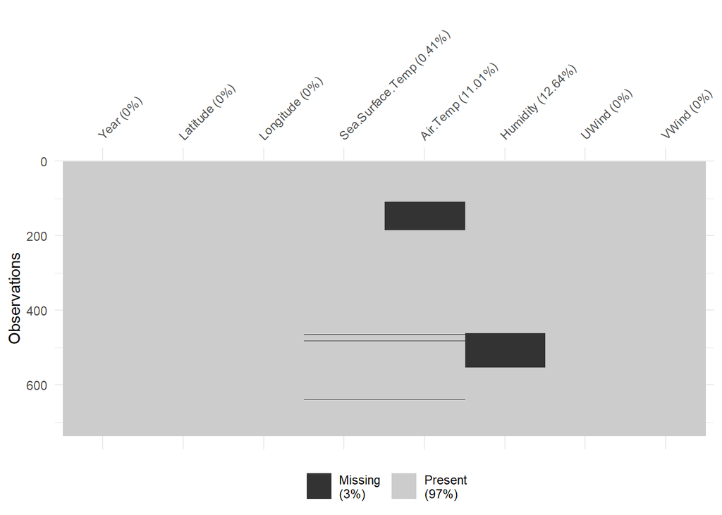

```r
vis_miss(tao)
```

- Con la función **‘gg_miss_case()’** nos regresa un gráfico o ggplot con el número de valores perdidos por caso. Puede ser considerado como el análogo visual de **’miss_case_summary?**

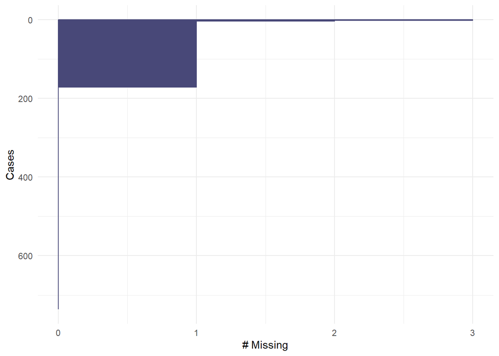

```r
gg_miss_case(tao)
```

- Con la función **‘gg_miss_upset()’** nos regresa # Valores perdidos de acuerdo a posibles combinaciones

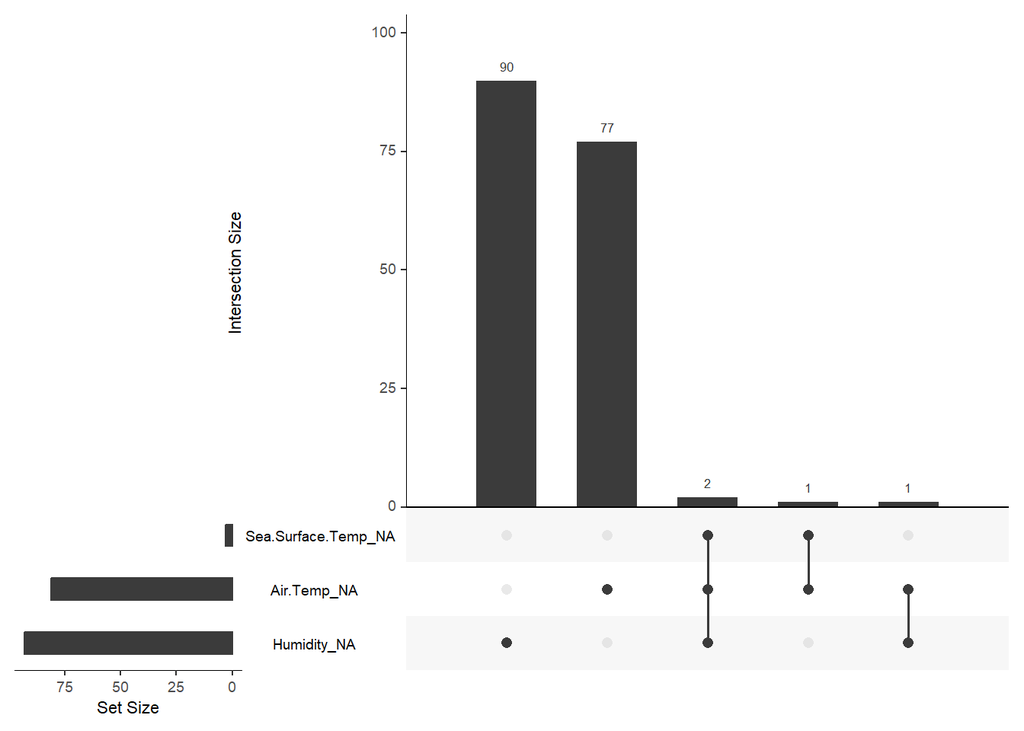

```r
gg_miss_upset(tao)
```

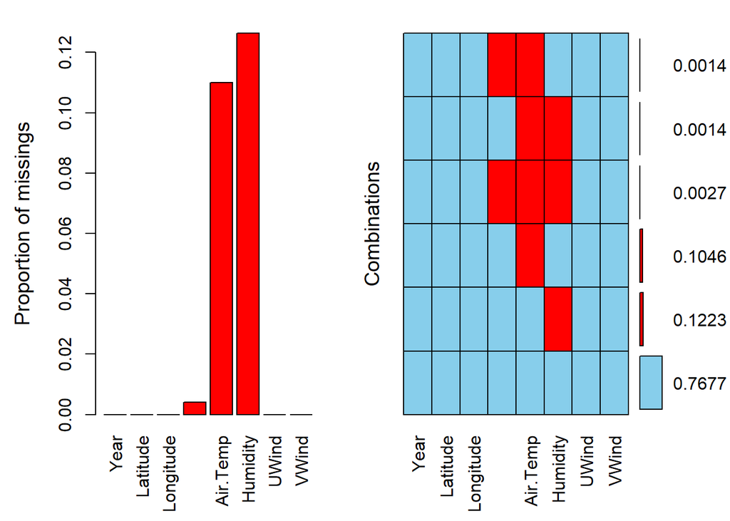

```r
# Podemos utilizar el Aggregation plot
a = aggr(tao,numbers=T)
```

```r
a # Nos da un pequeño resumen sobre nuestras variables
```

```
##
##  Missings in variables:
##          Variable Count
##  Sea.Surface.Temp     3
##          Air.Temp    81
##          Humidity    93
```

```r
summary(a)
```

```
##
##  Missings per variable:
##          Variable Count
##              Year     0
##          Latitude     0
##         Longitude     0
##  Sea.Surface.Temp     3
##          Air.Temp    81
##          Humidity    93
##             UWind     0
##             VWind     0
##
##  Missings in combinations of variables:
##     Combinations Count    Percent
##  0:0:0:0:0:0:0:0   565 76.7663043
##  0:0:0:0:0:1:0:0    90 12.2282609
##  0:0:0:0:1:0:0:0    77 10.4619565
##  0:0:0:0:1:1:0:0     1  0.1358696
##  0:0:0:1:1:0:0:0     1  0.1358696
##  0:0:0:1:1:1:0:0     2  0.2717391
```

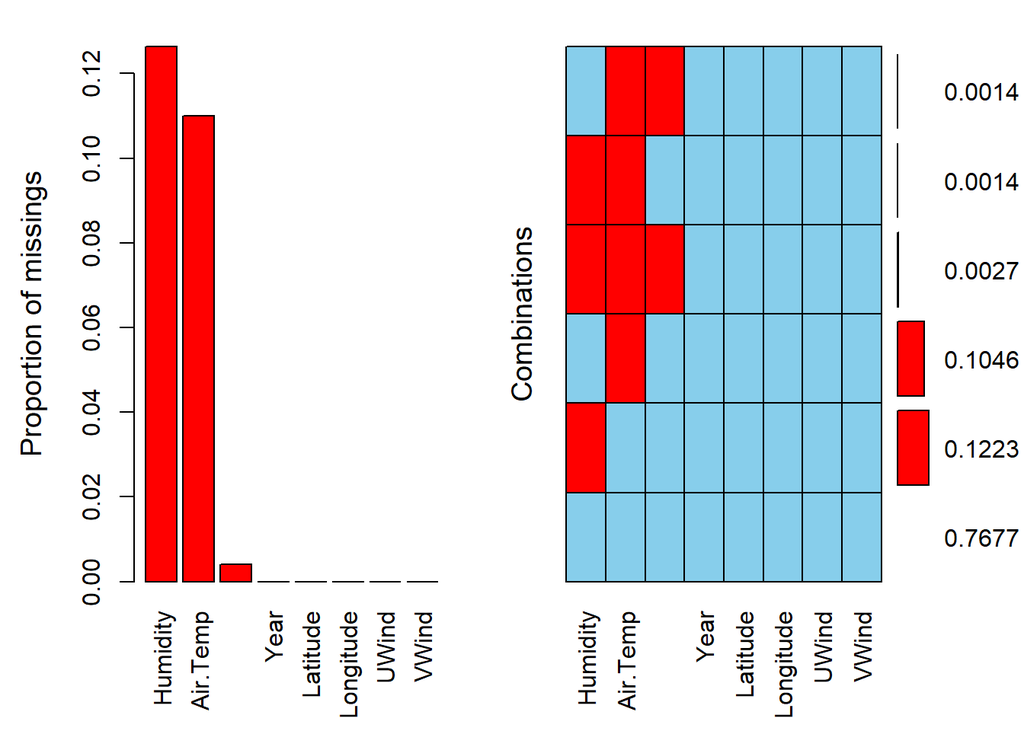

```
##
##  Variables sorted by number of missings:
##          Variable       Count
##          Humidity 0.126358696
##          Air.Temp 0.110054348
##  Sea.Surface.Temp 0.004076087
##              Year 0.000000000
##          Latitude 0.000000000
##         Longitude 0.000000000
##             UWind 0.000000000
##             VWind 0.000000000
```

```r
aggr(tao,numbers=T, sortComb=TRUE, sortVar=TRUE, only.miss=TRUE)
```

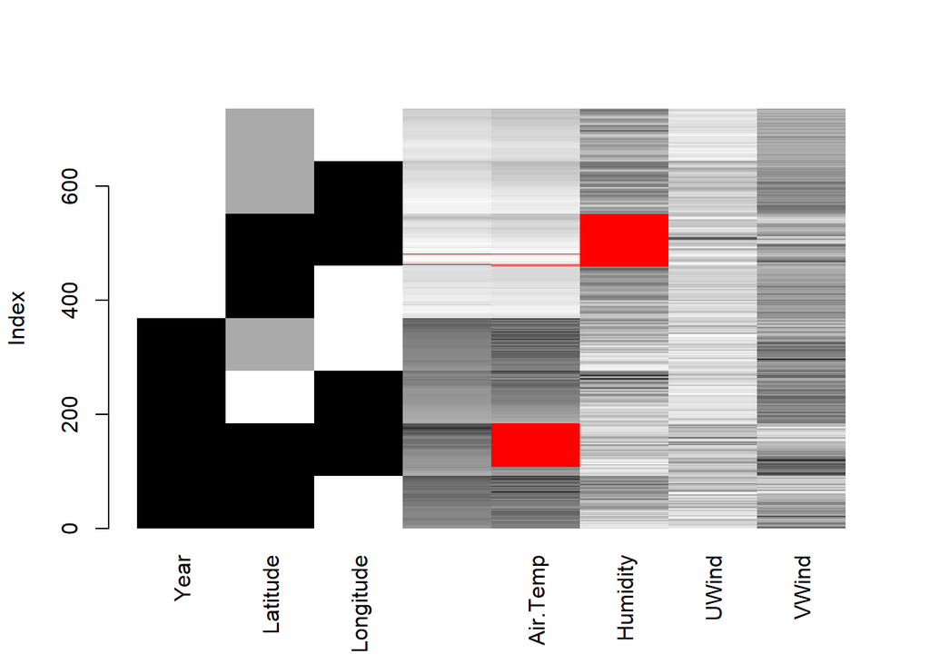

```r
# IDENTIFICACIÓN DE PATRÓN DE VP ----

## Mecanismo completamente aleatorio (MCAR)?
## O mecanismo aleatorio (MAR)?

matrixplot(tao)
```

```r
# Foto de tu dataset en colores.
# Rojo: Los datos faltantes
# Escala de grises según valores de vectores numéricos
# Para poder inspeccionar necesitamos que la gráfica sea interactiva y utilizamos x11()
x11()
VIM::pbox(tao[4:6], pos=1)
```

```
##
## Click in in the left margin to switch to the previous variable or in the right margin to switch to the next variable.
## To regain use of the VIM GUI and the R console, click anywhere else in the graphics window.
```